# Modeling Inoculum Availability of *Plurivorosphaerella nawae* in Persimmon Leaf Litter with Bayesian Beta Regression

2022-11-04

This is a simplified version of the paper [Martinez-Minaya et al., 2021](https://apsjournals.apsnet.org/doi/full/10.1094/PHYTO-08-20-0359-R). For a complete version of the problem, visit this [repository](https://bitbucket.org/joaquin-martinez-minaya/betapathogen/src)

```r
  library(dplyr)
  library(ggplot2)
  library(INLA)
```

# 1 Introduction to the problem

Circular leaf spot (CLS), caused by *Plurivorosphaerella nawae*, is a serious disease affecting persimmon that is characterized by:

- Necrotic lesions on leaves,
- Defoliation, and
- Fruit drop.

Under Mediterranean conditions, *P. nawae* forms pseudothecia in the leaf litter in winter, and ascospores are released in spring, infecting susceptible leaves. Persimmon growers are advised to apply fungicides for CLS control during the period of inoculum availability, which was previously defined based on ascospore counts under the microscope. A model of inoculum availability of *P. nawaew* has been developed and evaluated as an alternative to ascospore counts. Leaf litter samples were collected weekly in L’Alcudia (Spain) from 2010 to 2015. Leaves were soaked and placed in a wind tunnel, and the released ascospores of *P. nawae were counted.

# 2 Importing the data from L’Alcúdia

The models were constructed using the data from L’Alcúdia. The variables available are:

1. *y*: response variable. It is the proportion of ascospores. Note that in this exercise, the response variable has been previously transformed using the function *DR_data* from the package *DirichletReg*.
2. *year*: the year where the proportion of ascospores has been measured.
3. *dd*: acumulatted degree days. Biofix 01-01 and Tbase = 0ºC.

```r
# Ascospores data
# data <- readRDS("../data/data_khaki/alcudiadata_01-01.RDS")
# data <- data %>%
#   select(prop, Fe, anyo, dd) %>%
#   filter(dd <= 40)
#
# data$prop <- DirichletReg::DR_data(data$prop)[,2]
# colnames(data) <- c("y", "date", "year", "dd")
# writexl::write_xlsx(data, "../data/data_khaki/data_alcudia.xlsx")
#
data <- readxl::read_excel("../data/data_khaki/data_alcudia.xlsx")
data$year <- factor(data$year)
data <- data %>%
  dplyr::select(y, year, dd)
head(data)
```

| y | year | dd |
| --- | --- | --- |
| 0.001672241 | 2010 | 6.8632 |
| 0.001672241 | 2010 | 7.4725 |
| 0.011477706 | 2010 | 8.4572 |
| 0.031088637 | 2010 | 9.3737 |
| 0.070310499 | 2010 | 10.4184 |
| 0.100427285 | 2010 | 11.2742 |

# 3 Descriptive analysis

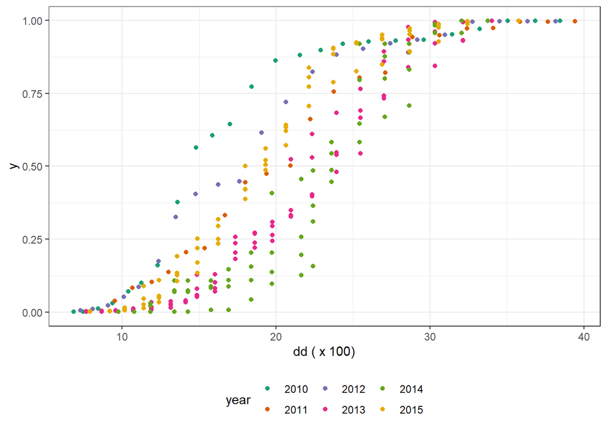

```r
  ggplot(data) +
  geom_point(aes(x = dd, y = y, col = year))+
  theme_bw() +
  theme(legend.position = "bottom") +
  scale_color_brewer(palette="Dark2") +
  xlab("dd ( x 100)")
```

# 4 The model: Hierarchical Bayesian Beta regression. Propose a model in mathematical notation.

# 5 Fit different models with fixed or random effect and select the best one

# 6 Best model

## 6.1 Represent the posterior distribution of the fixed effects

## 6.2 Represent the posterior distribution of the hyperparameters

# 7 Is the effect dd relevant in the model?

# 8 Now that we have the model, what would we do to make predictions?

# 9 Construct a grid between 5 and 40, an predict the proportion of ascospores